# Machine Learning Prediction Assignment

KW

February 28, 2016

# Summary

A random forest model provides a good algorithm for predicting the correctness of exercises with an accuracy rate of over 99%.

# Background

Groupware@LES performed a study of body movement measurements on six athletes performing a series of Unilateral Dumbbell Biceps Curls exercises in five different fashions: according to specification (Class A), throwing the elbows to the front (Class B), lifting the dumbbell only halfway (Class C), lowering the dumbbell only halfway (Class D), and throwing the hips to the front (Class E). The data was provided for analysis to determine if it was possible to predict the fashion in which the curl was being performed. Additional information and the research group’s paper can be found at http://groupware.les.inf.puc-rio.br/har.

# Model

The base training data set contains 19622 observations of 160 variables. Variable “classe” is the specification class we are trying to predict and is a factor variable of 5 levels (A, B, C, D, E) matching the classes of weight lifting fashions. The official test set will be cleansed along side in the same manner to provide a model match to use when predicting outcomes.

```r
dim(dTraining)
```

```
## [1] 19622   160
```

### Data Cleansing

In preparing the data for modeling, I first replaced all blank, “#DIV/0!”, and “NA” values with “0”.

```r
for (i in 8:159) {
        dTraining[,i] <- gsub("#DIV/0!|^$","0",dTraining[,i])
        finalTest[,i] <- gsub("#DIV/0!|^$","0",finalTest[,i])
}
dTraining[is.na(dTraining)] <- "0"
finalTest[is.na(finalTest)] <- "0"
```

The first seven columns are all factor data related to specifying information about the athlete and time period the activity was performed. These are not useful to the prediction model so they will be removed to simplify the model. The remaining variables, with the exception of the final variable “classe” contain numeric data but are not all indicated as numeric. They will be converted to numeric.

```r
dTraining <- dTraining[,-c(1:7)]
finalTest <- finalTest[,-c(1:7)]

idC <- c(5:ncol(dTraining)-1)
dTraining[,idC] = apply(dTraining[,idC], 2, function(x) as.numeric(as.character(x)))
finalTest[,idC] = apply(finalTest[,idC], 2, function(x) as.numeric(as.character(x)))
```

Now that the variables are all numeric, the variance within each variable can be checked and those which are close to zero can be removed: these will not make good predictors in the model.

```r
idxNearZero <- nearZeroVar(dTraining)
dTraining <- dTraining[,-idxNearZero]
finalTest <- finalTest[,-idxNearZero]
```

To train the data, the original training set is broken into two groups with 70% going to the training set and the remaining 30% set aside to test the model’s predictions.

```r
set.seed(13531)
trainIndex = createDataPartition(dTraining$classe, p = 0.70, list=FALSE)

setTraining = dTraining[trainIndex,]
setTesting = dTraining[-trainIndex,]
```

The resulting sets utilize 52 predictor variables plus the one that needs to be predicted.

```r
rbind("Original Dataset" = dim(dTraining),
      "Training Set" = dim(setTraining),
      "Testing Set" = dim(setTesting),
      "Final Test" = dim(finalTest))
```

```
##                   [,1] [,2]
## Original Dataset 19622   53
## Training Set     13737   53
## Testing Set       5885   53
## Final Test          20   53
```

### Model Creation

Random Forest is the first model selected to try as it is considered one of the most accurate algorithms although it can be one of the slowest.

```r
set.seed(24642)
modelFitRf <- randomForest(classe ~., data = setTraining, importance = TRUE, keep.forest = TRUE)
```

# Validation and Prediction

The test partition is run against the random forest model.

```r
modelPredict <- predict(modelFitRf, newdata = setTesting)

modelValidation <- setTesting
modelValidation$predicted <- modelPredict == setTesting$classe
# table(modelPredict, modelValidation$classe)
# modelPostResam <- postResample(modelPredict, modelValidation$classe)
```

Comparing the error rate of the training set to the error rate of the test set, the test set had a lower error rate (0.42%) compared to the training set (0.52%) as is expected with random forest models. The accuracy rate of the model when applied to the test set was 99.58%. No additional models will be selected to compare.

```r
modelConfMatrix <- confusionMatrix(modelPredict, modelValidation$classe)

modelAccuracy <- modelConfMatrix$overall[1]*100
modelAccuracy
```

```
## Accuracy
## 99.57519
```

```r
modelConfMatrixTable <- modelConfMatrix$table
modelConfMatrixTable
```

```
##           Reference
## Prediction    A    B    C    D    E
##          A 1673    6    0    0    0
##          B    1 1131    8    0    0
##          C    0    2 1016    3    0
##          D    0    0    2  960    2
##          E    0    0    0    1 1080
```

```r
trainErrorRate <- (nrow(setTraining) -
         (modelFitRf$confusion[1,1] + modelFitRf$confusion[2,2] +
                  modelFitRf$confusion[3,3] + modelFitRf$confusion[4,4] +
                  modelFitRf$confusion[5,5])) / nrow(setTraining)*100

testErrorRate <- (nrow(setTesting) -
         (modelConfMatrixTable[1,1] + modelConfMatrixTable[2,2] +
                  modelConfMatrixTable[3,3] + modelConfMatrixTable[4,4] +
                  modelConfMatrixTable[5,5])) / nrow(setTesting)*100

rbind(trainErrorRate,testErrorRate)
```

```
##                     [,1]
## trainErrorRate 0.5241319
## testErrorRate  0.4248088
```

### Variable Importance

Variables important to the model are as follows in the next figure.

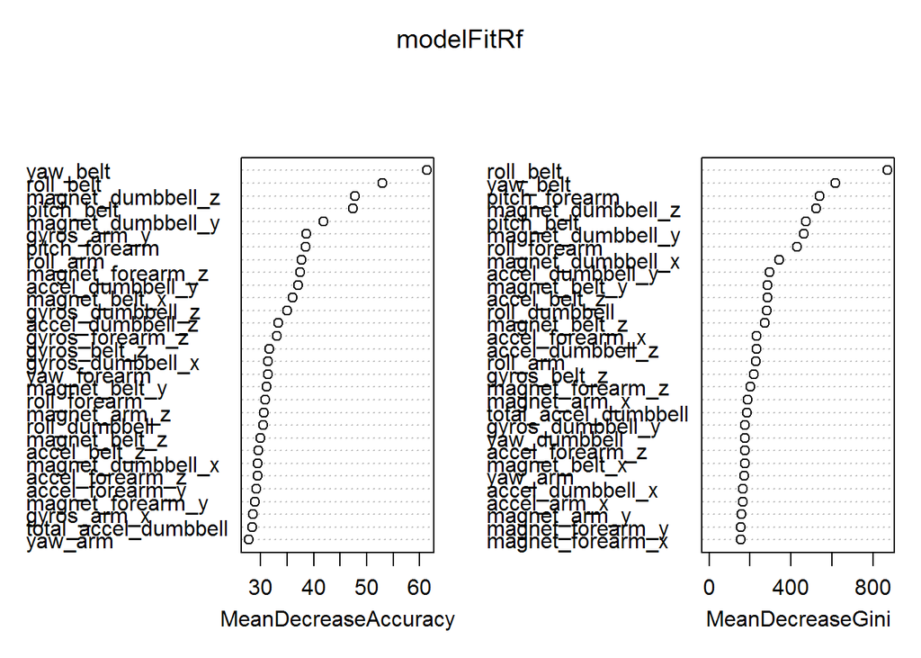

```r
varImpPlot(modelFitRf)
```